# Project 1 LDA Prova

## Visual representation of the paired data and correlations

Just to speed up the computations it is better to use the restricted dataset.

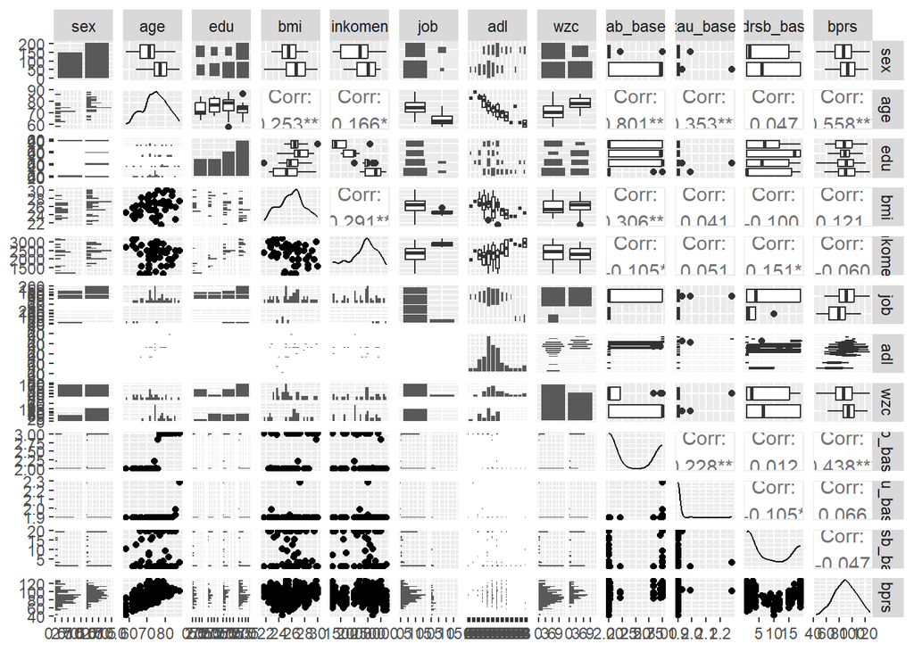

```r
ggpairs(alz_rist_long, columns = c(3:13, 16),
        cardinality_threshold = 21)
```

**COMMENTO DA RIFARE**

Just to be complete.

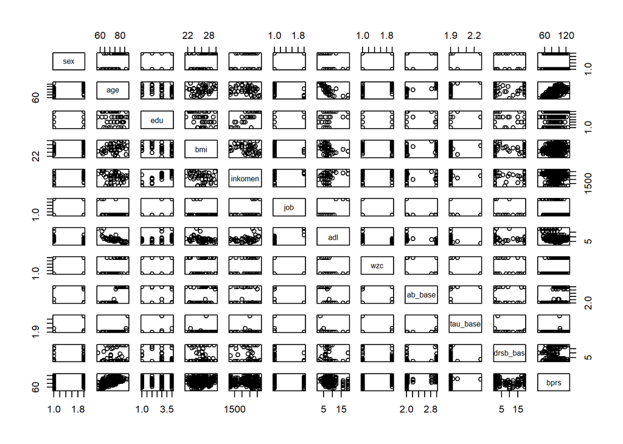

```r
pairs(alz_rist_long[, c(3:13, 16)])
```

## Covariance structure

*We could do it with the corrplot library? Don’t know maybe later on*

We need to study the possible covariance structure of the `bprs` variable.

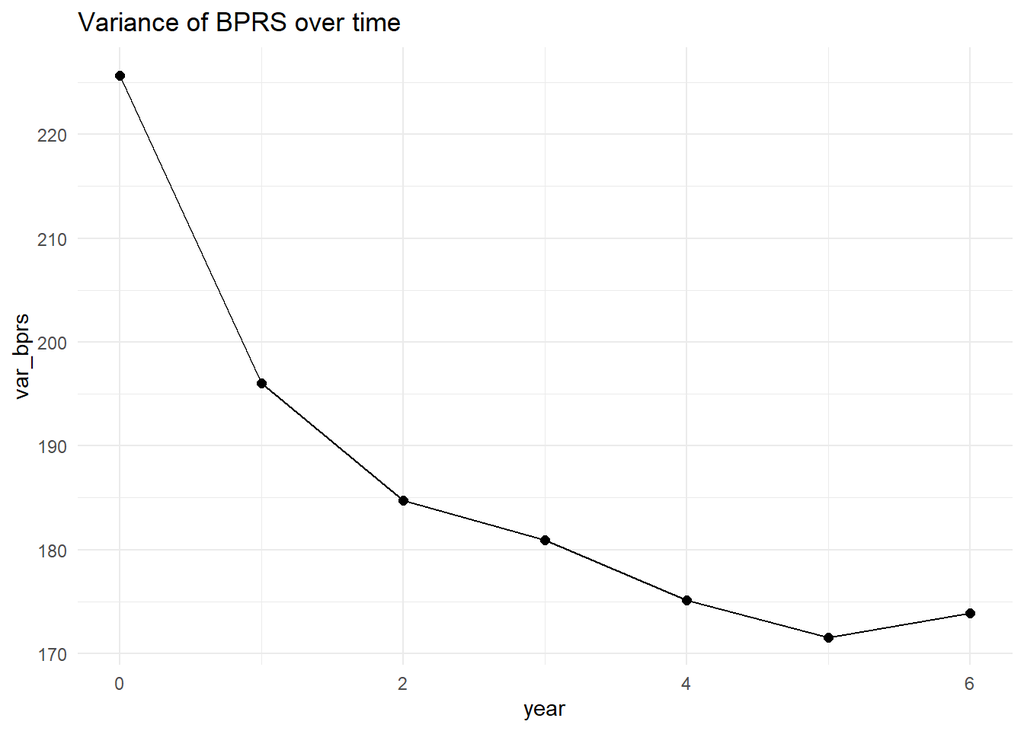

```r
var_by_year <- alz_long %>%
  group_by(year) %>%
  summarise(var_bprs = var(bprs, na.rm = TRUE))

ggplot(var_by_year, aes(x = year, y = var_bprs)) +
  geom_line() + geom_point(size=2) +
  theme_minimal() +
  labs(title = "Variance of BPRS over time")
```

It seems that the variance is decreasing over time, but not that significantly. In addition from time 1 to time 6 it is more or less constant (I guess that the high variance at the beginning is due to variability of the baseline values? This should be discussed a little bit better probably).

Now look at the covariance matrix.

```r
cov_matrix_bprs <- cov(alz[, c(18:24)], use = "pairwise.complete.obs")
round(cov_matrix_bprs, 2)
```

```
##        bprs0  bprs1  bprs2  bprs3  bprs4  bprs5  bprs6
## bprs0 225.68 191.11 177.05 168.89 157.11 147.63 141.44
## bprs1 191.11 196.04 179.86 172.35 160.54 151.41 145.49
## bprs2 177.05 179.86 184.72 176.01 165.38 157.22 151.36
## bprs3 168.89 172.35 176.01 180.90 167.65 159.94 156.06
## bprs4 157.11 160.54 165.38 167.65 175.17 164.42 161.64
## bprs5 147.63 151.41 157.22 159.94 164.42 171.58 167.46
## bprs6 141.44 145.49 151.36 156.06 161.64 167.46 173.85
```

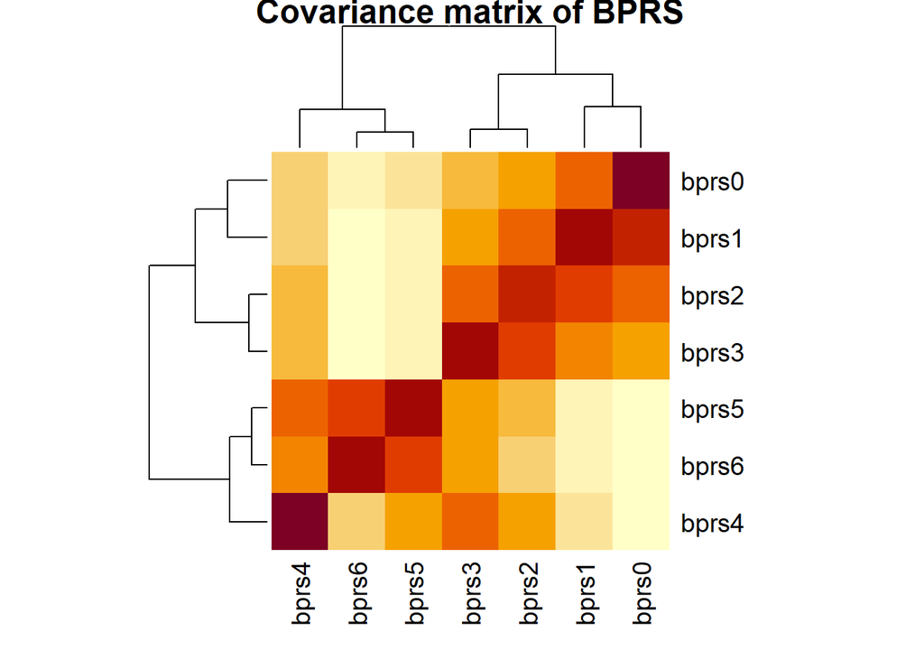

```r
heatmap(cov_matrix_bprs, main = "Covariance matrix of BPRS")
```

It seems that the variance is decreasing over time and in addition it seems that the correlation between the variables decreases over time. So we could exploit this fact into our analysis. However the covariance stays really high even within 6 years difference: probably the measures over the years are extremely correlated to the baseline (and so also to other values).

We can also have a look at the correlation matrix.

```r
cor_matrix_bprs <- cor(alz[, c(18:24)], use = "pairwise.complete.obs")
round(cor_matrix_bprs, 2)
```

```
##       bprs0 bprs1 bprs2 bprs3 bprs4 bprs5 bprs6
## bprs0  1.00  0.98  0.98  0.97  0.95  0.93  0.91
## bprs1  0.98  1.00  0.98  0.98  0.97  0.95  0.93
## bprs2  0.98  0.98  1.00  0.98  0.98  0.96  0.95
## bprs3  0.97  0.98  0.98  1.00  0.98  0.98  0.97
## bprs4  0.95  0.97  0.98  0.98  1.00  0.98  0.98
## bprs5  0.93  0.95  0.96  0.98  0.98  1.00  0.98
## bprs6  0.91  0.93  0.95  0.97  0.98  0.98  1.00
```

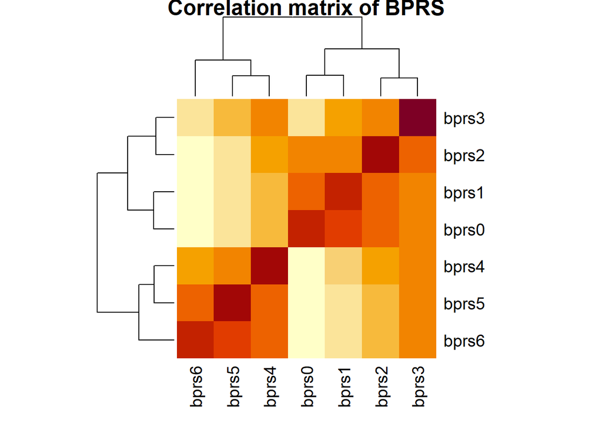

```r
heatmap(cor_matrix_bprs, main = "Correlation matrix of BPRS")
```

The correlation over time seems to be constant and almost equal to 1.

# Summary Statistics (definitely to be fixed)

Now we want to have a look at some possible summary statistics. The ones proposed during the lectures are: - analysis at each time point: could be interesting - analysis of area under the curve: doesn’t seem particularly interesting - analysis of endpoints: don’t know it doesn’t take into consideration possible differences in the baseline and in addition not every patient is up to 6 years of measurements - analysis of increments: interesting - analysis of covariance: *non ho capito come funziona*

## Analysis time points

### Time point 0

Should we try a linear regression? Should we try in a different way?

```r
mod_tp_0 <- lm(bprs0 ~ sex + age + edu + bmi +
                 inkomen + job + adl + wzc + cdrsb0 + abpet0 + taupet0,
               data = alz)

summary(mod_tp_0)
```

```
##
## Call:
## lm(formula = bprs0 ~ sex + age + edu + bmi + inkomen + job +
##     adl + wzc + cdrsb0 + abpet0 + taupet0, data = alz)
##
## Residuals:
##     Min      1Q  Median      3Q     Max
## -6.1359 -1.2345  0.0274  1.2982  6.3005
##
## Coefficients:
##               Estimate Std. Error t value Pr(>|t|)
## (Intercept) -1.169e+02  2.851e+00 -40.995  < 2e-16 ***
## sex1        -4.350e-02  1.922e-01  -0.226 0.820958
## age          2.344e+00  2.439e-02  96.089  < 2e-16 ***
## edu2         2.694e-01  2.300e-01   1.171 0.241703
## edu3         5.904e-01  2.977e-01   1.983 0.047619 *
## edu4         7.228e-01  4.058e-01   1.781 0.075150 .
## bmi          4.967e-01  2.938e-02  16.905  < 2e-16 ***
## inkomen     -4.705e-04  2.983e-04  -1.577 0.114964
## job1        -1.843e+01  6.450e-01 -28.575  < 2e-16 ***
## adl1        -2.306e+00  2.008e+00  -1.148 0.251008
## adl2        -2.661e-01  1.971e+00  -0.135 0.892624
## adl3         1.279e+00  1.951e+00   0.656 0.512127
## adl4         3.463e+00  1.946e+00   1.780 0.075406 .
## adl5         5.563e+00  1.947e+00   2.858 0.004336 **
## adl6         7.412e+00  1.950e+00   3.801 0.000152 ***
## adl7         9.411e+00  1.956e+00   4.811 1.69e-06 ***
## adl8         1.146e+01  1.962e+00   5.844 6.52e-09 ***
## adl9         1.382e+01  1.970e+00   7.013 3.84e-12 ***
## adl10        1.519e+01  1.995e+00   7.614 5.32e-14 ***
## adl11        1.858e+01  2.039e+00   9.115  < 2e-16 ***
## adl12        2.015e+01  2.085e+00   9.665  < 2e-16 ***
## adl13        2.171e+01  2.131e+00  10.189  < 2e-16 ***
## adl14        2.382e+01  2.158e+00  11.037  < 2e-16 ***
## adl15        2.502e+01  2.145e+00  11.667  < 2e-16 ***
## adl16        2.791e+01  2.165e+00  12.893  < 2e-16 ***
## adl17        3.050e+01  2.294e+00  13.296  < 2e-16 ***
## adl18        3.125e+01  2.271e+00  13.759  < 2e-16 ***
## adl19        3.272e+01  2.580e+00  12.680  < 2e-16 ***
## adl20        3.764e+01  2.601e+00  14.472  < 2e-16 ***
## wzc1         1.706e+00  1.317e-01  12.952  < 2e-16 ***
## cdrsb0      -1.958e-02  7.708e-03  -2.540 0.011219 *
## abpet0       4.608e-01  2.419e-01   1.905 0.057040 .
## taupet0      4.998e-01  5.788e-01   0.863 0.388096
## ---
## Signif. codes:  0 '***' 0.001 '**' 0.01 '*' 0.05 '.' 0.1 ' ' 1
##
## Residual standard error: 1.931 on 1220 degrees of freedom
## Multiple R-squared:  0.9839, Adjusted R-squared:  0.9835
## F-statistic:  2329 on 32 and 1220 DF,  p-value: < 2.2e-16
```

Then we can analyze these results? We can get the significant variables? I don’t know if there is anything else that could be interesting.

Should we try something different?

```r
## adl any 5
alz$adl_disc <- (as.numeric(alz$adl) %/% 5) * 5
alz$adl_disc <- as.factor(alz$adl_disc)

mod_tp_0 <- lm(bprs0 ~ sex + age + edu + bmi +
                 inkomen + job + adl_disc + wzc + cdrsb0 + abpet0 + taupet0,
               data = alz)

summary(mod_tp_0)
```

```
##
## Call:
## lm(formula = bprs0 ~ sex + age + edu + bmi + inkomen + job +
##     adl_disc + wzc + cdrsb0 + abpet0 + taupet0, data = alz)
##
## Residuals:
##     Min      1Q  Median      3Q     Max
## -7.7556 -1.7708 -0.1091  1.7893  7.7052
##
## Coefficients:
##               Estimate Std. Error t value Pr(>|t|)
## (Intercept) -84.414406   2.386923 -35.365  < 2e-16 ***
## sex1          0.043628   0.253153   0.172 0.863200
## age           1.957120   0.027590  70.937  < 2e-16 ***
## edu2          0.767960   0.305517   2.514 0.012075 *
## edu3          1.293992   0.391523   3.305 0.000977 ***
## edu4          1.912135   0.529981   3.608 0.000321 ***
## bmi           0.282807   0.038173   7.409 2.36e-13 ***
## inkomen      -0.001453   0.000387  -3.753 0.000183 ***
## job1        -10.095600   0.526470 -19.176  < 2e-16 ***
## adl_disc5     4.037103   0.315665  12.789  < 2e-16 ***
## adl_disc10    8.347504   0.439487  18.994  < 2e-16 ***
## adl_disc15   11.899320   0.781021  15.236  < 2e-16 ***
## adl_disc20   15.625471   1.583485   9.868  < 2e-16 ***
## wzc1          1.311548   0.175941   7.454 1.69e-13 ***
## cdrsb0       -0.024398   0.010327  -2.362 0.018307 *
## abpet0        2.213319   0.309758   7.145 1.53e-12 ***
## taupet0       1.744059   0.732209   2.382 0.017374 *
## ---
## Signif. codes:  0 '***' 0.001 '**' 0.01 '*' 0.05 '.' 0.1 ' ' 1
##
## Residual standard error: 2.608 on 1236 degrees of freedom
## Multiple R-squared:  0.9703, Adjusted R-squared:  0.9699
## F-statistic:  2520 on 16 and 1236 DF,  p-value: < 2.2e-16
```

### Time point 1

Should we try a linear regression? Should we try in a different way?

```r
mod_tp_1 <- lm(bprs1 ~ sex + age + edu + bmi +
                 inkomen + job + adl + wzc + cdrsb0 + abpet0 + taupet0,
               data = alz)

summary(mod_tp_1)
```

```
##
## Call:
## lm(formula = bprs1 ~ sex + age + edu + bmi + inkomen + job +
##     adl + wzc + cdrsb0 + abpet0 + taupet0, data = alz)
##
## Residuals:
##     Min      1Q  Median      3Q     Max
## -7.1248 -1.4676 -0.0013  1.3218  6.9217
##
## Coefficients:
##               Estimate Std. Error t value Pr(>|t|)
## (Intercept) -1.179e+02  3.768e+00 -31.280  < 2e-16 ***
## sex1        -4.748e-01  2.274e-01  -2.088   0.0370 *
## age          2.406e+00  2.944e-02  81.734  < 2e-16 ***
## edu2         4.590e-01  2.782e-01   1.650   0.0993 .
## edu3         5.016e-03  3.557e-01   0.014   0.9888
## edu4         8.610e-02  4.802e-01   0.179   0.8577
## bmi          5.122e-01  3.594e-02  14.253  < 2e-16 ***
## inkomen      1.880e-04  3.525e-04   0.533   0.5939
## job1        -1.942e+01  7.452e-01 -26.056  < 2e-16 ***
## adl3         4.075e+00  1.705e+00   2.389   0.0170 *
## adl4         6.801e+00  1.594e+00   4.267 2.15e-05 ***
## adl5         8.739e+00  1.590e+00   5.497 4.84e-08 ***
## adl6         1.057e+01  1.594e+00   6.633 5.21e-11 ***
## adl7         1.312e+01  1.601e+00   8.190 7.34e-16 ***
## adl8         1.535e+01  1.608e+00   9.545  < 2e-16 ***
## adl9         1.755e+01  1.620e+00  10.833  < 2e-16 ***
## adl10        1.910e+01  1.655e+00  11.540  < 2e-16 ***
## adl11        2.167e+01  1.721e+00  12.593  < 2e-16 ***
## adl12        2.363e+01  1.799e+00  13.137  < 2e-16 ***
## adl13        2.685e+01  1.868e+00  14.369  < 2e-16 ***
## adl14        2.871e+01  1.910e+00  15.028  < 2e-16 ***
## adl15        3.095e+01  1.888e+00  16.397  < 2e-16 ***
## adl16        3.210e+01  1.917e+00  16.745  < 2e-16 ***
## adl17        3.545e+01  2.106e+00  16.836  < 2e-16 ***
## adl18        3.635e+01  2.072e+00  17.550  < 2e-16 ***
## adl19        3.921e+01  2.504e+00  15.659  < 2e-16 ***
## adl20        3.974e+01  2.535e+00  15.678  < 2e-16 ***
## wzc1         1.953e+00  1.611e-01  12.123  < 2e-16 ***
## cdrsb0      -3.947e-02  9.569e-03  -4.125 3.99e-05 ***
## abpet0       2.568e-01  2.941e-01   0.873   0.3828
## taupet0      2.143e-01  1.419e+00   0.151   0.8799
## ---
## Signif. codes:  0 '***' 0.001 '**' 0.01 '*' 0.05 '.' 0.1 ' ' 1
##
## Residual standard error: 2.215 on 1075 degrees of freedom
##   (147 osservazioni eliminate a causa di valori mancanti)
## Multiple R-squared:  0.9757, Adjusted R-squared:  0.975
## F-statistic:  1436 on 30 and 1075 DF,  p-value: < 2.2e-16
```

Should we compare the results with other time points?

### Time point 2

Should we try a linear regression? Should we try in a different way?

```r
mod_tp_2 <- lm(bprs2 ~ sex + age + edu + bmi +
                 inkomen + job + adl + wzc + cdrsb2 + abpet2 + taupet2,
               data = alz)

summary(mod_tp_2)
```

```
##
## Call:
## lm(formula = bprs2 ~ sex + age + edu + bmi + inkomen + job +
##     adl + wzc + cdrsb2 + abpet2 + taupet2, data = alz)
##
## Residuals:
##     Min      1Q  Median      3Q     Max
## -8.3288 -1.9198 -0.0191  1.9314  9.7372
##
## Coefficients:
##               Estimate Std. Error t value Pr(>|t|)
## (Intercept) -1.114e+02  4.444e+00 -25.063  < 2e-16 ***
## sex1        -1.442e-01  2.987e-01  -0.483  0.62927
## age          2.390e+00  4.208e-02  56.801  < 2e-16 ***
## edu2         2.194e-01  3.641e-01   0.603  0.54684
## edu3         1.848e-01  4.672e-01   0.395  0.69260
## edu4         1.966e-01  6.291e-01   0.313  0.75468
## bmi          4.932e-01  4.656e-02  10.593  < 2e-16 ***
## inkomen      6.538e-05  4.614e-04   0.142  0.88734
## job1        -1.886e+01  9.387e-01 -20.088  < 2e-16 ***
## adl4         6.880e+00  2.810e+00   2.448  0.01453 *
## adl5         9.220e+00  2.799e+00   3.294  0.00102 **
## adl6         1.172e+01  2.804e+00   4.178 3.20e-05 ***
## adl7         1.377e+01  2.812e+00   4.896 1.14e-06 ***
## adl8         1.611e+01  2.818e+00   5.718 1.43e-08 ***
## adl9         1.869e+01  2.830e+00   6.606 6.45e-11 ***
## adl10        2.006e+01  2.863e+00   7.007 4.50e-12 ***
## adl11        2.186e+01  2.930e+00   7.461 1.88e-13 ***
## adl12        2.371e+01  3.002e+00   7.899 7.50e-15 ***
## adl13        2.773e+01  3.074e+00   9.019  < 2e-16 ***
## adl14        2.837e+01  3.107e+00   9.131  < 2e-16 ***
## adl15        3.031e+01  3.093e+00   9.799  < 2e-16 ***
## adl16        3.361e+01  3.119e+00  10.774  < 2e-16 ***
## adl17        3.720e+01  3.315e+00  11.224  < 2e-16 ***
## adl18        3.620e+01  3.283e+00  11.027  < 2e-16 ***
## adl19        3.494e+01  3.727e+00   9.373  < 2e-16 ***
## adl20        3.935e+01  3.770e+00  10.438  < 2e-16 ***
## wzc1         2.108e+00  2.146e-01   9.825  < 2e-16 ***
## cdrsb2      -3.646e-02  1.804e-02  -2.021  0.04358 *
## abpet2       4.054e-01  3.835e-01   1.057  0.29066
## taupet2      7.363e-01  8.118e-01   0.907  0.36460
## ---
## Signif. codes:  0 '***' 0.001 '**' 0.01 '*' 0.05 '.' 0.1 ' ' 1
##
## Residual standard error: 2.766 on 984 degrees of freedom
##   (239 osservazioni eliminate a causa di valori mancanti)
## Multiple R-squared:  0.9598, Adjusted R-squared:  0.9586
## F-statistic: 809.4 on 29 and 984 DF,  p-value: < 2.2e-16
```

### Time point 3

Should we try a linear regression? Should we try in a different way?

```r
mod_tp_3 <- lm(bprs3 ~ sex + age + edu + bmi +
                 inkomen + job + adl + wzc + cdrsb3 + abpet3 + taupet3,
               data = alz)

summary(mod_tp_3)
```

```
##
## Call:
## lm(formula = bprs3 ~ sex + age + edu + bmi + inkomen + job +
##     adl + wzc + cdrsb3 + abpet3 + taupet3, data = alz)
##
## Residuals:
##     Min      1Q  Median      3Q     Max
## -11.817  -2.241  -0.076   2.310  10.241
##
## Coefficients:
##               Estimate Std. Error t value Pr(>|t|)
## (Intercept) -9.542e+01  4.329e+00 -22.042  < 2e-16 ***
## sex1        -2.751e-01  3.805e-01  -0.723  0.46985
## age          2.330e+00  5.628e-02  41.407  < 2e-16 ***
## edu2         5.758e-01  4.749e-01   1.213  0.22563
## edu3         3.962e-01  5.971e-01   0.663  0.50719
## edu4         2.214e-02  8.013e-01   0.028  0.97796
## bmi          4.900e-01  6.014e-02   8.148 1.27e-15 ***
## inkomen      2.555e-04  5.838e-04   0.438  0.66176
## job1        -1.783e+01  1.162e+00 -15.341  < 2e-16 ***
## adl5         3.000e+00  9.512e-01   3.154  0.00167 **
## adl6         4.582e+00  9.306e-01   4.924 1.01e-06 ***
## adl7         6.673e+00  9.481e-01   7.039 3.91e-12 ***
## adl8         9.252e+00  9.704e-01   9.535  < 2e-16 ***
## adl9         1.131e+01  1.012e+00  11.175  < 2e-16 ***
## adl10        1.295e+01  1.140e+00  11.363  < 2e-16 ***
## adl11        1.344e+01  1.346e+00   9.979  < 2e-16 ***
## adl12        1.599e+01  1.551e+00  10.307  < 2e-16 ***
## adl13        1.950e+01  1.760e+00  11.075  < 2e-16 ***
## adl14        2.081e+01  1.840e+00  11.313  < 2e-16 ***
## adl15        2.214e+01  1.792e+00  12.352  < 2e-16 ***
## adl16        2.454e+01  1.859e+00  13.203  < 2e-16 ***
## adl17        2.720e+01  2.308e+00  11.785  < 2e-16 ***
## adl18        2.767e+01  2.236e+00  12.378  < 2e-16 ***
## adl19        2.642e+01  3.120e+00   8.468  < 2e-16 ***
## adl20        2.775e+01  3.202e+00   8.666  < 2e-16 ***
## wzc1         2.175e+00  2.931e-01   7.421 2.74e-13 ***
## cdrsb3      -4.740e-02  2.620e-02  -1.809  0.07075 .
## abpet3       9.725e-01  4.873e-01   1.996  0.04628 *
## taupet3      1.138e+00  8.095e-01   1.406  0.15998
## ---
## Signif. codes:  0 '***' 0.001 '**' 0.01 '*' 0.05 '.' 0.1 ' ' 1
##
## Residual standard error: 3.382 on 878 degrees of freedom
##   (346 osservazioni eliminate a causa di valori mancanti)
## Multiple R-squared:  0.9387, Adjusted R-squared:  0.9368
## F-statistic: 480.5 on 28 and 878 DF,  p-value: < 2.2e-16
```

### Time point 4

Should we try a linear regression? Should we try in a different way?

```r
mod_tp_4 <- lm(bprs4 ~ sex + age + edu + bmi +
                 inkomen + job + adl + wzc + cdrsb4 + abpet4 + taupet4,
               data = alz)

summary(mod_tp_4)
```

```
##
## Call:
## lm(formula = bprs4 ~ sex + age + edu + bmi + inkomen + job +
##     adl + wzc + cdrsb4 + abpet4 + taupet4, data = alz)
##
## Residuals:
##      Min       1Q   Median       3Q      Max
## -11.6768  -2.8299  -0.0729   2.9230  12.5808
##
## Coefficients:
##               Estimate Std. Error t value Pr(>|t|)
## (Intercept) -8.820e+01  6.141e+00 -14.362  < 2e-16 ***
## sex1        -1.741e-01  4.752e-01  -0.366 0.714190
## age          2.248e+00  7.363e-02  30.527  < 2e-16 ***
## edu2         1.307e+00  6.017e-01   2.172 0.030178 *
## edu3         1.359e+00  7.548e-01   1.801 0.072098 .
## edu4         1.222e+00  1.002e+00   1.219 0.223174
## bmi          4.887e-01  7.785e-02   6.277 5.86e-10 ***
## inkomen     -2.890e-04  7.211e-04  -0.401 0.688679
## job1        -1.911e+01  1.429e+00 -13.378  < 2e-16 ***
## adl5         4.024e+00  2.966e+00   1.357 0.175307
## adl6         5.341e+00  2.916e+00   1.832 0.067388 .
## adl7         7.280e+00  2.918e+00   2.495 0.012807 *
## adl8         1.005e+01  2.930e+00   3.431 0.000634 ***
## adl9         1.207e+01  2.946e+00   4.098 4.63e-05 ***
## adl10        1.351e+01  3.012e+00   4.483 8.50e-06 ***
## adl11        1.423e+01  3.133e+00   4.542 6.51e-06 ***
## adl12        1.704e+01  3.265e+00   5.219 2.33e-07 ***
## adl13        2.181e+01  3.409e+00   6.397 2.78e-10 ***
## adl14        2.272e+01  3.478e+00   6.533 1.19e-10 ***
## adl15        2.274e+01  3.445e+00   6.602 7.69e-11 ***
## adl16        2.784e+01  3.494e+00   7.968 6.00e-15 ***
## adl17        2.982e+01  3.869e+00   7.708 4.07e-14 ***
## adl18        2.954e+01  3.805e+00   7.763 2.74e-14 ***
## adl19        2.861e+01  4.620e+00   6.193 9.76e-10 ***
## adl20        3.177e+01  4.700e+00   6.760 2.79e-11 ***
## wzc1         1.832e+00  4.046e-01   4.528 6.93e-06 ***
## cdrsb4       4.652e-02  3.040e-02   1.530 0.126356
## abpet4       2.201e+00  6.197e-01   3.552 0.000407 ***
## taupet4      1.975e+00  9.357e-01   2.111 0.035118 *
## ---
## Signif. codes:  0 '***' 0.001 '**' 0.01 '*' 0.05 '.' 0.1 ' ' 1
##
## Residual standard error: 4.058 on 748 degrees of freedom
##   (476 osservazioni eliminate a causa di valori mancanti)
## Multiple R-squared:  0.9094, Adjusted R-squared:  0.906
## F-statistic: 268.1 on 28 and 748 DF,  p-value: < 2.2e-16
```

### Time point 5

Should we try a linear regression? Should we try in a different way?

```r
mod_tp_5 <- lm(bprs5 ~ sex + age + edu + bmi +
                 inkomen + job + adl + wzc + cdrsb5 + abpet5 + taupet5,
               data = alz)

summary(mod_tp_5)
```

```
##
## Call:
## lm(formula = bprs5 ~ sex + age + edu + bmi + inkomen + job +
##     adl + wzc + cdrsb5 + abpet5 + taupet5, data = alz)
##
## Residuals:
##      Min       1Q   Median       3Q      Max
## -12.2904  -3.3543  -0.1141   3.1221  16.1350
##
## Coefficients:
##               Estimate Std. Error t value Pr(>|t|)
## (Intercept) -8.384e+01  7.434e+00 -11.277  < 2e-16 ***
## sex1        -3.579e-01  5.982e-01  -0.598   0.5498
## age          2.367e+00  9.467e-02  25.008  < 2e-16 ***
## edu2         5.611e-01  7.667e-01   0.732   0.4646
## edu3         1.203e+00  9.349e-01   1.286   0.1988
## edu4         3.863e-01  1.227e+00   0.315   0.7531
## bmi          4.836e-01  1.012e-01   4.778 2.21e-06 ***
## inkomen      2.049e-04  8.789e-04   0.233   0.8157
## job1        -1.974e+01  1.732e+00 -11.399  < 2e-16 ***
## adl6         1.634e+00  1.793e+00   0.911   0.3624
## adl7         4.196e+00  1.781e+00   2.356   0.0188 *
## adl8         7.413e+00  1.793e+00   4.135 4.03e-05 ***
## adl9         9.075e+00  1.835e+00   4.945 9.79e-07 ***
## adl10        1.165e+01  1.986e+00   5.866 7.25e-09 ***
## adl11        1.185e+01  2.247e+00   5.274 1.84e-07 ***
## adl12        1.460e+01  2.521e+00   5.790 1.12e-08 ***
## adl13        1.905e+01  2.785e+00   6.839 1.91e-11 ***
## adl14        1.997e+01  2.916e+00   6.847 1.81e-11 ***
## adl15        2.185e+01  2.851e+00   7.665 6.86e-14 ***
## adl16        2.453e+01  2.940e+00   8.343 4.67e-16 ***
## adl17        2.922e+01  3.569e+00   8.188 1.50e-15 ***
## adl18        2.766e+01  3.471e+00   7.969 7.64e-15 ***
## adl19        2.565e+01  4.709e+00   5.448 7.35e-08 ***
## adl20        2.778e+01  4.834e+00   5.746 1.43e-08 ***
## wzc1         1.280e+00  5.719e-01   2.237   0.0256 *
## cdrsb5       1.257e-01  3.202e-02   3.925 9.65e-05 ***
## abpet5       1.445e+00  7.631e-01   1.893   0.0588 .
## taupet5      7.653e-01  1.054e+00   0.726   0.4681
## ---
## Signif. codes:  0 '***' 0.001 '**' 0.01 '*' 0.05 '.' 0.1 ' ' 1
##
## Residual standard error: 4.76 on 624 degrees of freedom
##   (601 osservazioni eliminate a causa di valori mancanti)
## Multiple R-squared:  0.8734, Adjusted R-squared:  0.8679
## F-statistic: 159.5 on 27 and 624 DF,  p-value: < 2.2e-16
```

### Time point 6

Should we try a linear regression? Should we try in a different way?

```r
mod_tp_6 <- lm(bprs6 ~ sex + age + edu + bmi +
                 inkomen + job + adl + wzc + cdrsb6 + abpet6 + taupet6,
               data = alz)

summary(mod_tp_6)
```

```
##
## Call:
## lm(formula = bprs6 ~ sex + age + edu + bmi + inkomen + job +
##     adl + wzc + cdrsb6 + abpet6 + taupet6, data = alz)
##
## Residuals:
##      Min       1Q   Median       3Q      Max
## -15.0237  -3.4937  -0.0145   3.3143  16.6044
##
## Coefficients:
##               Estimate Std. Error t value Pr(>|t|)
## (Intercept) -6.102e+01  1.076e+01  -5.670 2.46e-08 ***
## sex1        -5.372e-01  7.789e-01  -0.690  0.49068
## age          2.353e+00  1.199e-01  19.626  < 2e-16 ***
## edu2         8.141e-01  1.021e+00   0.797  0.42579
## edu3         1.539e+00  1.223e+00   1.259  0.20875
## edu4        -2.941e-01  1.601e+00  -0.184  0.85433
## bmi          3.665e-01  1.329e-01   2.759  0.00602 **
## inkomen      6.341e-04  1.082e-03   0.586  0.55827
## job1        -1.901e+01  2.086e+00  -9.110  < 2e-16 ***
## adl6        -1.335e+01  5.624e+00  -2.373  0.01801 *
## adl7        -9.662e+00  5.539e+00  -1.744  0.08173 .
## adl8        -6.663e+00  5.539e+00  -1.203  0.22962
## adl9        -4.103e+00  5.553e+00  -0.739  0.46033
## adl10       -2.636e+00  5.613e+00  -0.470  0.63887
## adl11       -1.875e+00  5.752e+00  -0.326  0.74452
## adl12       -5.677e-02  5.905e+00  -0.010  0.99233
## adl13        4.328e+00  6.053e+00   0.715  0.47493
## adl14        5.996e+00  6.142e+00   0.976  0.32945
## adl15        6.803e+00  6.103e+00   1.115  0.26555
## adl16        1.149e+01  6.153e+00   1.868  0.06241 .
## adl17        1.426e+01  6.604e+00   2.159  0.03134 *
## adl18        1.277e+01  6.530e+00   1.955  0.05113 .
## adl19        1.302e+01  7.506e+00   1.735  0.08345 .
## adl20        1.421e+01  7.647e+00   1.858  0.06375 .
## wzc1         1.961e+00  8.859e-01   2.213  0.02734 *
## cdrsb6       1.382e-01  3.424e-02   4.038 6.28e-05 ***
## abpet6       2.283e+00  1.053e+00   2.169  0.03057 *
## taupet6      9.641e-02  1.324e+00   0.073  0.94199
## ---
## Signif. codes:  0 '***' 0.001 '**' 0.01 '*' 0.05 '.' 0.1 ' ' 1
##
## Residual standard error: 5.472 on 483 degrees of freedom
##   (742 osservazioni eliminate a causa di valori mancanti)
## Multiple R-squared:  0.8369, Adjusted R-squared:  0.8278
## F-statistic: 91.77 on 27 and 483 DF,  p-value: < 2.2e-16
```

It seems that the $R^2$ value is decreasing over time to me. In addition we could analyze the different values of the parameter? I don’t know…

First of all we will create a few new data to work on.

```r
## Remove NA in the bprs

alz1 <- alz[!is.na(alz$bprs1),]
alz2 <- alz1[!is.na(alz1$bprs2),]
alz3 <- alz2[!is.na(alz2$bprs3),]
alz4 <- alz3[!is.na(alz3$bprs4),]
alz5 <- alz4[!is.na(alz4$bprs5),]
alz6 <- alz5[!is.na(alz5$bprs6),]

## Now we can compute the AUC values
```

## t-test

```r
t.test(alz[alz$sex == 1, ]$bprs1, alz[alz$sex == 0, ]$bprs1)
```

```
##
##  Welch Two Sample t-test
##
## data:  alz[alz$sex == 1, ]$bprs1 and alz[alz$sex == 0, ]$bprs1
## t = 6.7291, df = 1089.8, p-value = 2.753e-11
## alternative hypothesis: true difference in means is not equal to 0
## 95 percent confidence interval:
##  3.942726 7.188497
## sample estimates:
## mean of x mean of y
##  83.16252  77.59691
```

## Analysis of endpoints

Probably it is better to look at the baseline values before going on with the analysis of endpoints.

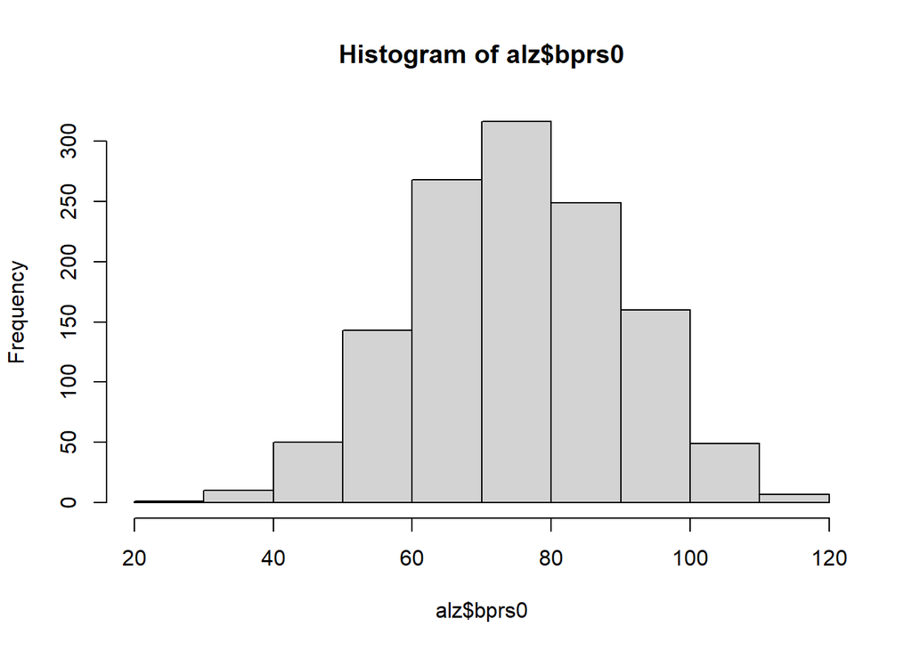

```r
hist(alz$bprs0)
```

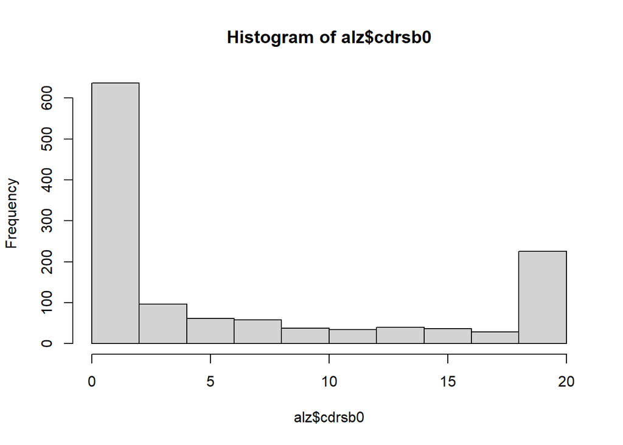

```r
hist(alz$cdrsb0)
```

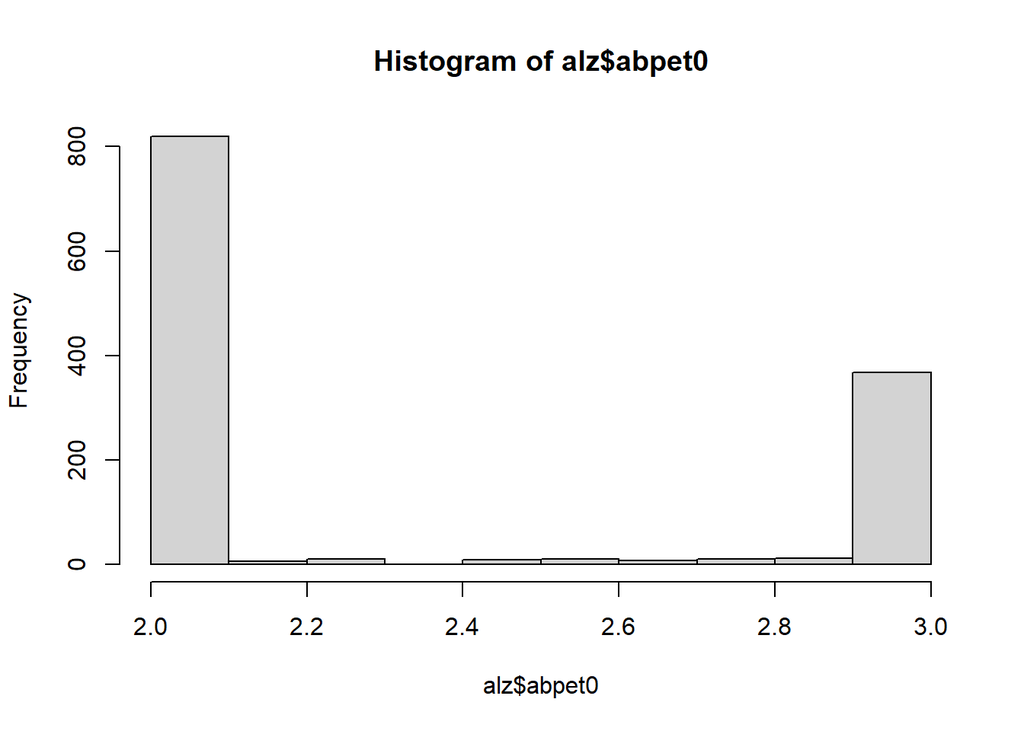

```r
hist(alz$abpet0)
```

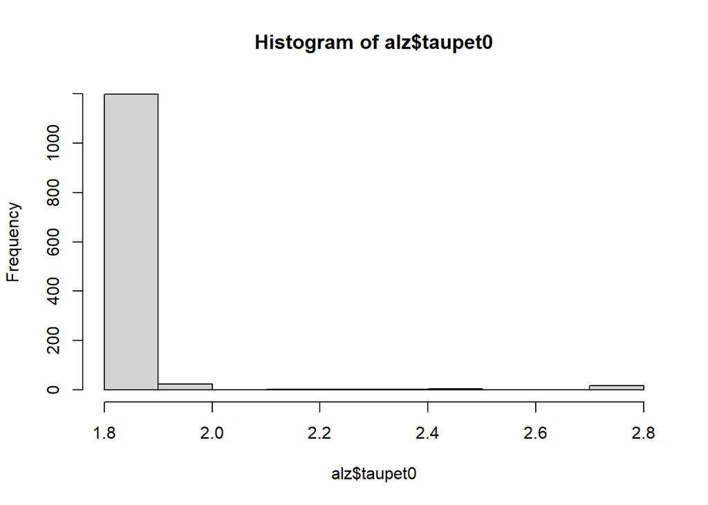

```r
hist(alz$taupet0)
```

The values are not exactly the same so I don’t know if it could work. In addition we don’t have the same endpoints? How could it work? Also we need to fix a little bit the data set (add the last biomarker measurement…)

## Analysis of increments (da migliorare un po’ ma idea base ci dovrebbe essere)

We need to play with our dataset. We can create a new one because it is easier.

```r
alz_inc <- alz

# Compute the increments
alz_inc$cdrsbinc0 <- rep(0, length(alz_inc$patid))
alz_inc$cdrsbinc1 <- alz_inc$cdrsb1 - alz_inc$cdrsb0
alz_inc$cdrsbinc2 <- alz_inc$cdrsb2 - alz_inc$cdrsb0
alz_inc$cdrsbinc3 <- alz_inc$cdrsb3 - alz_inc$cdrsb0
alz_inc$cdrsbinc4 <- alz_inc$cdrsb4 - alz_inc$cdrsb0
alz_inc$cdrsbinc5 <- alz_inc$cdrsb5 - alz_inc$cdrsb0
alz_inc$cdrsbinc6 <- alz_inc$cdrsb6 - alz_inc$cdrsb0

alz_inc$bprsinc0 <- rep(0, length(alz_inc$patid))
alz_inc$bprsinc1 <- alz_inc$bprs1 - alz_inc$bprs0
alz_inc$bprsinc2 <- alz_inc$bprs2 - alz_inc$bprs0
alz_inc$bprsinc3 <- alz_inc$bprs3 - alz_inc$bprs0
alz_inc$bprsinc4 <- alz_inc$bprs4 - alz_inc$bprs0
alz_inc$bprsinc5 <- alz_inc$bprs5 - alz_inc$bprs0
alz_inc$bprsinc6 <- alz_inc$bprs6 - alz_inc$bprs0

alz_inc$abpetinc0 <- rep(0, length(alz_inc$patid))
alz_inc$abpetinc1 <- alz_inc$abpet1 - alz_inc$abpet0
alz_inc$abpetinc2 <- alz_inc$abpet2 - alz_inc$abpet0
alz_inc$abpetinc3 <- alz_inc$abpet3 - alz_inc$abpet0
alz_inc$abpetinc4 <- alz_inc$abpet4 - alz_inc$abpet0
alz_inc$abpetinc5 <- alz_inc$abpet5 - alz_inc$abpet0
alz_inc$abpetinc6 <- alz_inc$abpet6 - alz_inc$abpet0

alz_inc$taupetinc0 <- rep(0, length(alz_inc$patid))
alz_inc$taupetinc1 <- alz_inc$taupet1 - alz_inc$taupet0
alz_inc$taupetinc2 <- alz_inc$taupet2 - alz_inc$taupet0
alz_inc$taupetinc3 <- alz_inc$taupet3 - alz_inc$taupet0
alz_inc$taupetinc4 <- alz_inc$taupet4 - alz_inc$taupet0
alz_inc$taupetinc5 <- alz_inc$taupet5 - alz_inc$taupet0
alz_inc$taupetinc6 <- alz_inc$taupet6 - alz_inc$taupet0

## Now go back to the dataframe structure
alz_inc_df <- data.frame(alz_inc)

alz_inc_long <- alz_inc_df %>%
  pivot_longer(
    # 1️⃣ Seleziona tutte le colonne che iniziano con cdrsb, abpet o taupet,
    #     seguite da un numero (0–6)
    cols = matches("^(bprs|cdrsb|abpet|taupet|bprsinc|cdrsbinc|abpetinc|taupetinc)\\d+$"),

    # 2️⃣ Crea due nuove colonne:
    #     - ".value" → il prefisso (cdrsb, abpet, taupet)
    #     - "year"   → il numero alla fine
    names_to = c(".value", "year"),

    # 3️⃣ Divide i nomi in due parti: (prefisso, numero)
    names_pattern = "(bprs|cdrsb|abpet|taupet|bprsinc|cdrsbinc|abpetinc|taupetinc)(\\d+)"
  ) %>%
  mutate(
    year = as.numeric(year),                            # converte in numerico
    sample = factor(rep(1:nrow(alz_inc_df), each = 7)) # ID per ogni paziente
  )
```

Now we can work a little bit on the results.

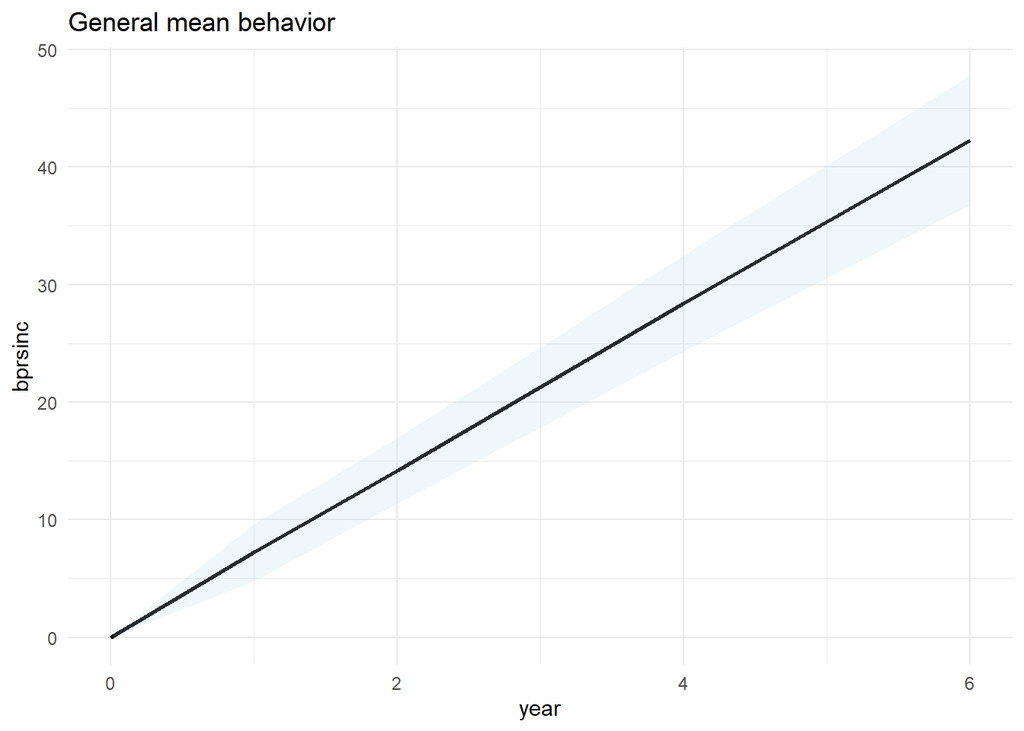

```r
## General behavior

ggplot(alz_inc_long, aes(x = year, y = bprsinc)) +
  stat_summary(fun = mean, geom = "line", size = 1) +
  stat_summary(fun.data = mean_sdl, geom = "ribbon", fun.args = list(mult = 1),
               alpha = 0.2, fill = "lightblue") +
  theme_minimal() +
  labs(title = "General mean behavior")
```

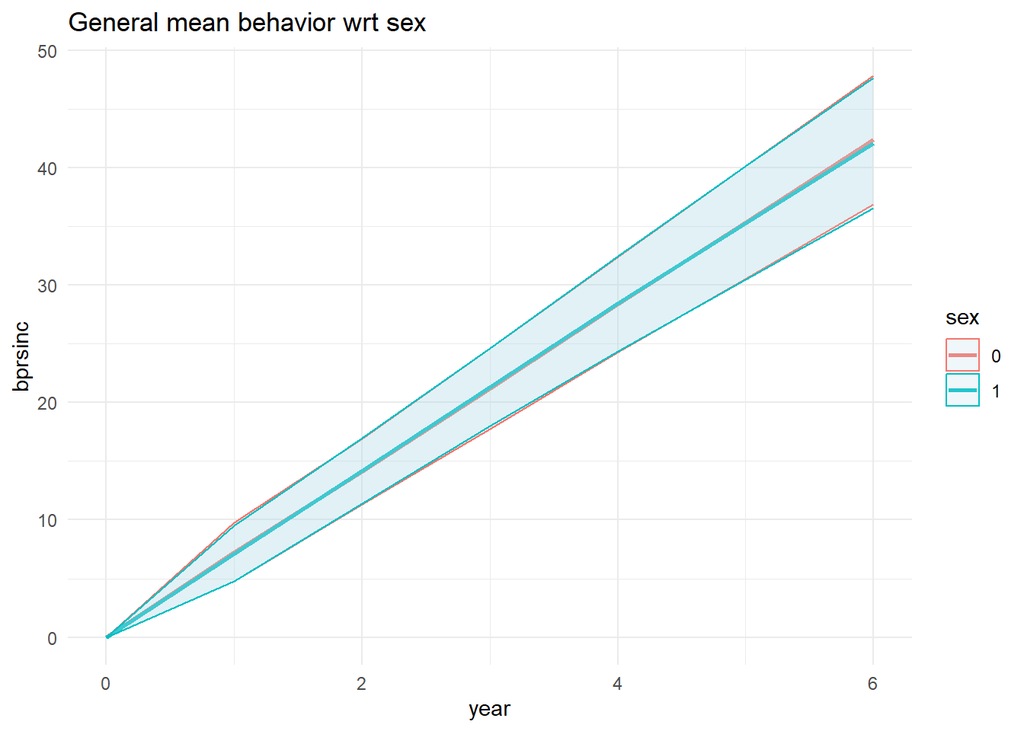

```r
ggplot(alz_inc_long, aes(x = year, y = bprsinc, group = sex, color = sex)) +
  stat_summary(fun = mean, geom = "line", size = 1) +
  stat_summary(fun.data = mean_sdl, geom = "ribbon", fun.args = list(mult = 1),
               alpha = 0.2, fill = "lightblue") +
  theme_minimal() +
  labs(title = "General mean behavior wrt sex")
```

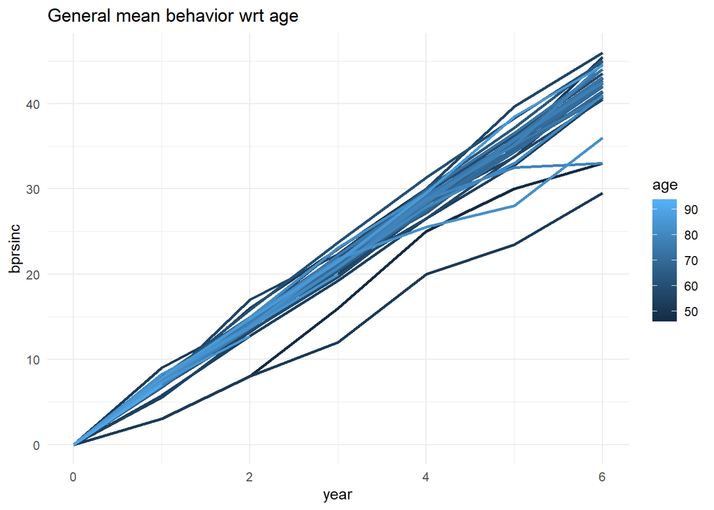

```r
ggplot(alz_inc_long, aes(x = year, y = bprsinc, group = age, color = age)) +
  stat_summary(fun = mean, geom = "line", size = 1) +
  #stat_summary(fun.data = mean_sdl, geom = "ribbon", fun.args = list(mult = 1),
  #             alpha = 0.2, fill = "lightblue") +
  theme_minimal() +
  labs(title = "General mean behavior wrt age")
```

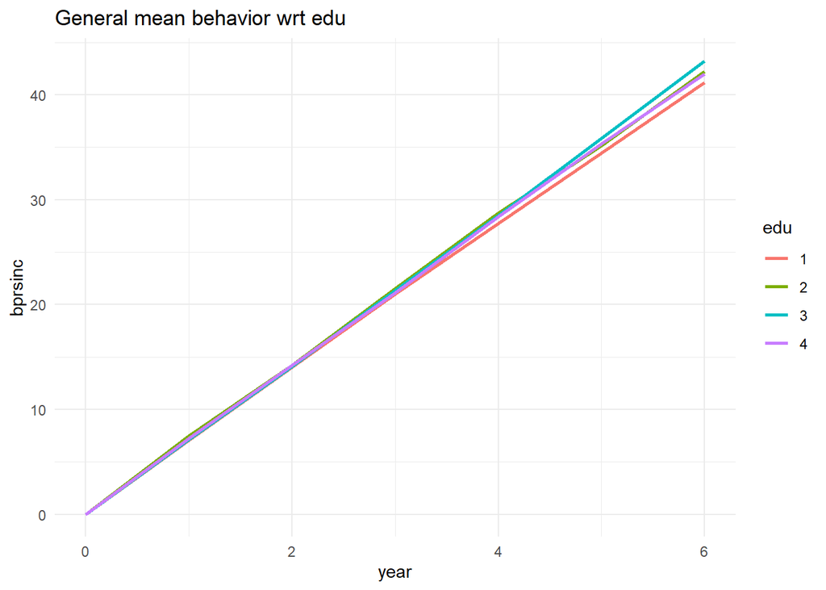

```r
ggplot(alz_inc_long, aes(x = year, y = bprsinc, group = edu, color = edu)) +
  stat_summary(fun = mean, geom = "line", size = 1) +
  #stat_summary(fun.data = mean_sdl, geom = "ribbon", fun.args = list(mult = 1),
  #             alpha = 0.2, fill = "lightblue") +
  theme_minimal() +
  labs(title = "General mean behavior wrt edu")
```

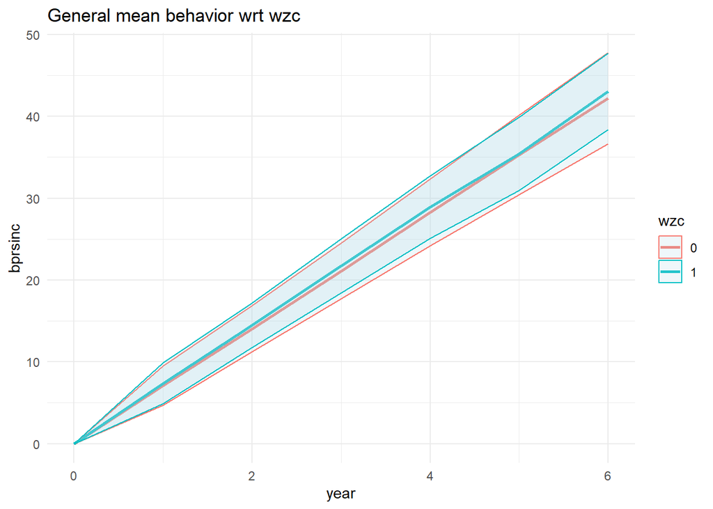

```r
ggplot(alz_inc_long, aes(x = year, y = bprsinc, group = wzc, color = wzc)) +
  stat_summary(fun = mean, geom = "line", size = 1) +
  stat_summary(fun.data = mean_sdl, geom = "ribbon", fun.args = list(mult = 1),
               alpha = 0.2, fill = "lightblue") +
  theme_minimal() +
  labs(title = "General mean behavior wrt wzc")
```

*Complete any combination…*

It seems that the slopes are the same for any group: this is coherent with our previous conclusions!

# Multivariate Model

Now we want to try to fit a multivariate model to our data.

```r
library(nlme)
library(lmtest)
library(DescTools)
```

We can start by fitting for example the most general model that includes everything. We will use the AR(1) covariance structure because it is too complex to fit otherwise. The problem here is that we also need to reduce the number of parameters to fit (because it is too complex otherwise).

```r
mult_model_1 <- gls(
  bprs ~ age + edu + bmi + inkomen + adl + wzc + cdrsb_base + ab_base + tau_base +
    (sex + job) * year ,
  correlation = corAR1(form = ~ year | sample),  # struttura UN
  method = "ML",
  data = alz_long,
  na.action = na.exclude
)

mult_model_1$coefficients
```

```
##   (Intercept)           age          edu2          edu3          edu4
## -1.235458e+02  2.437389e+00  2.275461e-01  2.443034e-01 -2.716713e-01
##           bmi       inkomen          adl1          adl2          adl3
##  5.004956e-01  4.964403e-04 -1.991395e+00  2.454388e-01  1.843133e+00
##          adl4          adl5          adl6          adl7          adl8
##  4.266801e+00  6.664084e+00  8.561918e+00  1.070587e+01  1.325261e+01
##          adl9         adl10         adl11         adl12         adl13
##  1.558787e+01  1.727698e+01  1.902209e+01  2.122953e+01  2.477232e+01
##         adl14         adl15         adl16         adl17         adl18
##  2.614640e+01  2.738769e+01  3.074050e+01  3.417946e+01  3.388740e+01
##         adl19         adl20          wzc1    cdrsb_base       ab_base
##  3.453431e+01  3.705125e+01  1.976990e+00 -6.840327e-02 -4.599172e-02
##      tau_base          sex1          job1          year     sex1:year
## -2.929002e-01 -4.966100e-01 -1.909785e+01  7.082535e+00 -1.273648e-02
##     job1:year
## -6.251021e-02
```

```r
moda <- function(x) {
  x <- na.omit(x)
  ux <- unique(x)
  ux[which.max(tabulate(match(x, ux)))]
}
```

IDEA: calcola valori medi e la moda e confronta i vari risultati con la media generica

```r
sex_moda <- moda(alz$sex)
age_mean <- mean(alz$age)
edu_moda <- moda(alz$edu)
bmi_mean <- mean(alz$bmi)
ink_mean <- mean(alz$inkomen)
job_moda <- moda(alz$job)
adl_moda <- moda(alz$adl)
wzc_moda <- moda(alz$wzc)
cdrsb_mean <- mean(alz$cdrsb0)
ab_mean <- mean(alz$abpet0)
tau_mean <- mean(alz$taupet0)

mean_values <- c(sex_moda, age_mean, edu_moda, bmi_mean, ink_mean, job_moda,
                 adl_moda, wzc_moda, cdrsb_mean, ab_mean, tau_mean)

## Build a dataframe to predict the values
anni <- 2020:2025

# Costruisci il data frame di predizione

anni <- 0:6

mean_df <- data.frame(
  sex = factor(rep(sex_moda, 7), levels = levels(alz_long$sex)),
  age = rep(age_mean, 7),
  edu = factor(rep(edu_moda, 7), levels = levels(alz_long$edu)),
  bmi = rep(bmi_mean, 7),
  inkomen = rep(ink_mean, 7),
  job = factor(rep(job_moda, 7), levels = levels(alz_long$job)),
  adl = factor(rep(adl_moda, 7), levels = levels(alz_long$adl)),
  wzc = factor(rep(wzc_moda, 7), levels = levels(alz_long$wzc)),
  bprs = c(mean(alz$bprs0), mean(na.omit(alz$bprs1)), mean(na.omit(alz$bprs2)),
           mean(na.omit(alz$bprs3)), mean(na.omit(alz$bprs4)),
           mean(na.omit(alz$bprs5)), mean(na.omit(alz$bprs6))),
  cdrsb_base = rep(cdrsb_mean, 7),
  ab_base = rep(ab_mean, 7),
  tau_base = rep(tau_mean, 7),
  year = anni,
  sample = rep("media", 7)  # oppure un valore valido esistente in alz_long$sample
)
```

Now we can predict the mean values over time

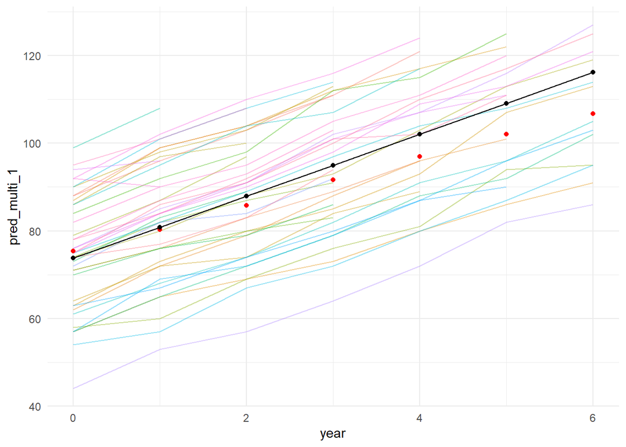

```r
mean_df$pred_multi_1 <- predict(mult_model_1, mean_df)

ggplot(mean_df, aes(x = year, y = pred_multi_1)) +
  geom_line(data = alz_rist_long,
            aes(x = year, y = bprs, group = sample, color = sample), alpha = 0.4,
            show.legend = FALSE) +
  geom_point(data = mean_df, aes(x = year, y = bprs), color = "red") +
  geom_line(alpha = 1, show.legend = FALSE) +
  geom_point() +
  theme_minimal()
```

It seems that it does not predict well over time. Now we can compare for example different groups.

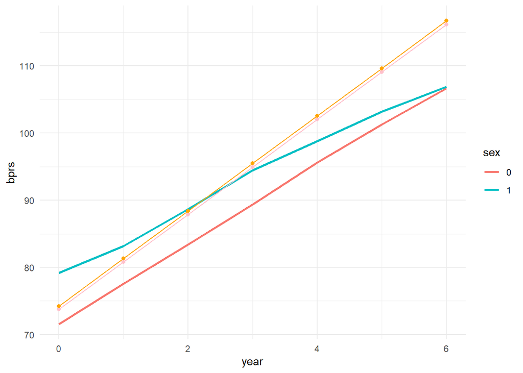

```r
df_prova_1 <- mean_df
df_prova_1$sex <- factor(rep(0, 7), levels = levels(alz_long$sex))
df_prova_1$pred_multi_1 <- predict(mult_model_1, df_prova_1)

## Comparison
ggplot(alz_long, aes(x = year, y = bprs, group = sex, color = sex)) +
  stat_summary(fun = mean, geom = "line", size = 1) +
  #stat_summary(fun.data = mean_sdl, geom = "ribbon", fun.args = list(mult = 1),
  #             alpha = 0.2, fill = "lightblue") +
  geom_point(data = mean_df, aes(x = year, y = pred_multi_1), color = "pink") +
  geom_line(data = mean_df, aes(x = year, y = pred_multi_1), color = "pink") +
  geom_point(data = df_prova_1, aes(x = year, y = pred_multi_1), color = "orange") +
  geom_line(data = df_prova_1, aes(x = year, y = pred_multi_1), color = "orange") +
  theme_minimal()
```

For example this is not captured really well.

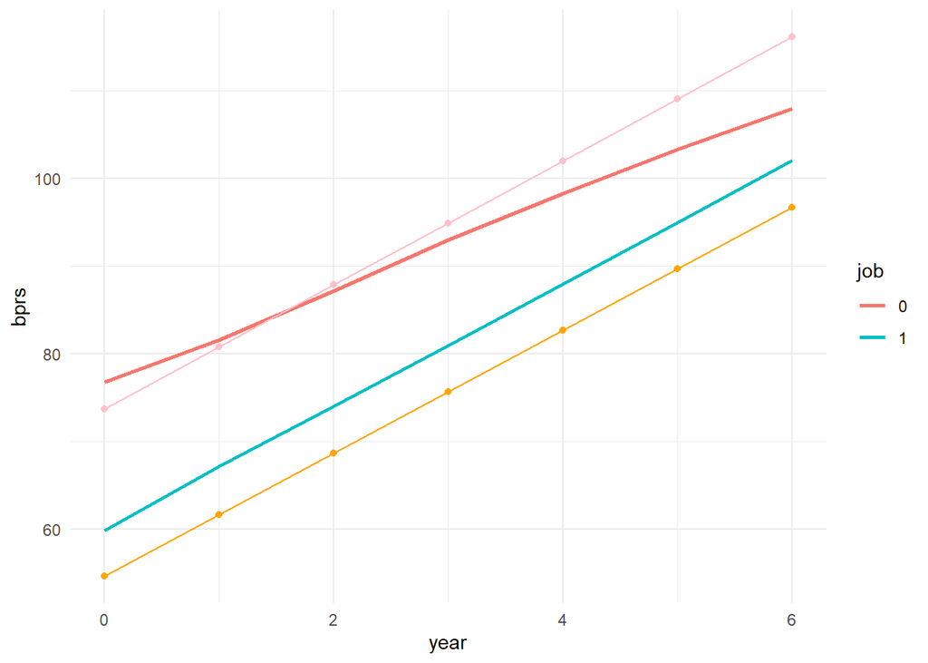

```r
df_prova_2 <- mean_df
df_prova_2$job <- factor(rep(1, 7), levels = levels(alz_long$sex))
df_prova_2$pred_multi_1 <- predict(mult_model_1, df_prova_2)

## Comparison
ggplot(alz_long, aes(x = year, y = bprs, group = job, color = job)) +
  stat_summary(fun = mean, geom = "line", size = 1) +
  #stat_summary(fun.data = mean_sdl, geom = "ribbon", fun.args = list(mult = 1),
  #             alpha = 0.2, fill = "lightblue") +
  geom_point(data = mean_df, aes(x = year, y = pred_multi_1), color = "pink") +
  geom_line(data = mean_df, aes(x = year, y = pred_multi_1), color = "pink") +
  geom_point(data = df_prova_2, aes(x = year, y = pred_multi_1), color = "orange") +
  geom_line(data = df_prova_2, aes(x = year, y = pred_multi_1), color = "orange") +
  theme_minimal()
```

For example for job it works way better.

We coudld do something similar also with other variables.

## Parsimonious model

```r
mult_model_2 <- gls(
  bprs ~ age + edu + bmi + inkomen + adl + wzc + cdrsb_base + ab_base + tau_base +
    (sex + job) * year ,
  correlation = corAR1(form = ~ year | sample),  # struttura UN
  method = "ML",
  data = alz_long,
  na.action = na.exclude
)

AIC(mult_model_1, mult_model_2)
```

```
##              df      AIC
## mult_model_1 38 29095.28
## mult_model_2 38 29095.28
```

**MMM MISSA CHE SONO GIA ARRIVATO IO AL MODELLO PIU PARSIMONIOSO DALL’EXPLORATORY DATA ANALYSIS…**